# Chimeric RNA evidence audit and baseline benchmark

This pilot asks whether simple rankings recover published independent RNA support within a selected probe panel. The source is [Venezia et al., Nature (2026)](https://doi.org/10.1038/s41586-026-10982-x). It does not predict protein existence or biological function.

## Findings

The 529 probe sequences represent 527 ordered gene pairs. 109 pairs are listed as NanoString-supported. There are **no established biological negatives**. Only 479 panel pairs exactly match the main read catalogue. The comparison below uses the development partition; the reserved held-out partition is not evaluated.

## Methods and assumptions

The initial evaluation unit is an **ordered gene pair**, because the published confirmation list does not identify particular probe variants, reads or samples. Unreported support remains unknown. We keep shared parental genes and duplicate sequences in the same split, compare methods on one eligible pool, and average ties analytically. The interval columns describe tie-breaking variability, not confidence about biological truth.

```python
from pathlib import Path
import json
import pandas as pd
from IPython.display import display, Image
from chrna.data import build
from chrna.benchmark import benchmark, plot
root = Path.cwd()
if not (root / 'pyproject.toml').exists():
    root = root.parent
assert (root / 'pyproject.toml').exists(), 'Run from the repository or notebooks directory'
pd.set_option('display.max_colwidth', 75)
```

## Sources and data quality

Original spreadsheet downloads are checksum-pinned. The feature table and evaluation outcomes are separate files. Raw sequencing reads are not required for this pilot.

```python
audit = build(root)
summary_keys = ['catalogue_read_records', 'catalogue_gene_pairs', 'probe_records', 'probe_gene_pairs', 'nanostring_supported_gene_pairs', 'exact_catalogue_matches', 'known_true_negatives']
display(pd.DataFrame({'Quantity': summary_keys, 'Count': [audit[k] for k in summary_keys]}))
```

|  | Quantity | Count |
| --- | --- | --- |
| 0 | catalogue_read_records | 36826 |
| 1 | catalogue_gene_pairs | 30390 |
| 2 | probe_records | 529 |
| 3 | probe_gene_pairs | 527 |
| 4 | nanostring_supported_gene_pairs | 109 |
| 5 | exact_catalogue_matches | 479 |
| 6 | known_true_negatives | 0 |

```python
sources = pd.read_json(root / 'data/sources.json')
display(sources[['name', 'description', 'sha256']])
```

|  | name | description | sha256 |
| --- | --- | --- | --- |
| 0 | supplementary-table-1.xlsx | Mouse sample metadata | bdc728d03edb59ccab315d371e46088ae52ab2944d770d39aa3561be49b2ecca |
| 1 | supplementary-table-3.xlsx | Repaired mouse candidate read records | 26188b51627c0c804fd102b605e81c083866ae4253d845f2f3bbc45fcf3d71ce |
| 2 | supplementary-table-7.xlsx | Published gene-pair confirmation lists | 6edb01e329d622100da30c47cd8eeaf7589a325d2ab94fb06f27c0f088a7f131 |
| 3 | supplementary-table-8.xlsx | NanoString probe design sequences | 601adceec614d56f70f7ecd636278e8df13f2bf9c8dc96c6de0991ce5230cc00 |
| 4 | supplementary-table-10.xlsx | Human sample metadata | d4ddbf6fef7e19c04b5736dbae5256ba2b24d75399959b4240f262e307f4820c |

### Name matching and probe variants

A missing match is never converted to zero support. Reverse-name matches require junction verification. The two pairs with multiple probes remain one pair each in the benchmark.

```python
display(pd.DataFrame(audit['catalogue_match_counts'].items(), columns=['Match status', 'Pairs']))
print('Pairs with multiple probes:', ', '.join(audit['multi_probe_pairs']))
candidates = pd.read_csv(root / 'data/processed/candidate_pairs.csv')
display(candidates.loc[~candidates.baseline_eligible, ['pair_id','catalogue_match']].head(8))
```

|  | Match status | Pairs |
| --- | --- | --- |
| 0 | exact_ordered_pair | 479 |
| 1 | not_found_in_table_3 | 47 |
| 2 | reverse_name_only_unresolved_junction | 1 |

```
Pairs with multiple probes: Slc16a10:Rpf2, Slc25a13:Sem1
```

|  | pair_id | catalogue_match |
| --- | --- | --- |
| 55 | Btrc:Fbxw4 | not_found_in_table_3 |
| 76 | Ctsb:Clec2d | not_found_in_table_3 |
| 118 | Gramd1a:Xdh | not_found_in_table_3 |
| 176 | Mrpl40:Sh3bgrl3 | not_found_in_table_3 |
| 183 | Msrb1:Mir155hg | not_found_in_table_3 |
| 184 | Mt1:Paip2b | not_found_in_table_3 |
| 188 | Mx2:Slc30a7 | not_found_in_table_3 |
| 192 | Myo5a:Pcid2 | not_found_in_table_3 |

### Split integrity

Connected components are formed from parental genes and identical sequences without outcome labels. Fold 4 is reserved. These splits do not eliminate all protein/gene-family homology.

```python
display(candidates.groupby(['partition','fold']).agg(Pairs=('pair_id','size'), Eligible_pairs=('baseline_eligible','sum')).reset_index())
splits = pd.read_csv(root / 'data/processed/splits.csv')
genes_by_fold = {fold: set(g.gene_a) | set(g.gene_b) for fold, g in splits.groupby('fold')}
assert all(not genes_by_fold[a] & genes_by_fold[b] for a in genes_by_fold for b in genes_by_fold if a < b)
print('Verified: no parental gene crosses folds.')
```

|  | partition | fold | Pairs | Eligible_pairs |
| --- | --- | --- | --- | --- |
| 0 | development | 0 | 106 | 94 |
| 1 | development | 1 | 106 | 94 |
| 2 | development | 2 | 105 | 94 |
| 3 | development | 3 | 105 | 96 |
| 4 | heldout | 4 | 105 | 101 |

```
Verified: no parental gene crosses folds.
```

## Development results

The fixed baselines use no NanoString outcome to calculate scores. Reported short-read support is an additional assay-derived comparator, not a sequence-only prediction. All three methods receive the same eligible development pool.

```python
results = benchmark(root, partition='development')
display(results[['method','k','expected_supported_at_k','known_positive_recall_at_k','tie_breaking_lower_95','tie_breaking_upper_95']].round(3))
```

|  | method | k | expected_supported_at_k | known_positive_recall_at_k | tie_breaking_lower_95 | tie_breaking_upper_95 |
| --- | --- | --- | --- | --- | --- | --- |
| 0 | Random selection | 10 | 2.275 | 0.026 | 0.0 | 5.0 |
| 1 | Random selection | 20 | 4.550 | 0.053 | 1.0 | 8.0 |
| 2 | Random selection | 50 | 11.376 | 0.132 | 6.0 | 17.0 |
| 3 | Long-read support | 10 | 7.000 | 0.081 | 6.0 | 8.0 |
| 4 | Long-read support | 20 | 10.477 | 0.122 | 9.0 | 13.0 |
| 5 | Long-read support | 50 | 16.805 | 0.195 | 12.0 | 22.0 |
| 6 | Reported short-read support | 10 | 5.455 | 0.063 | 3.0 | 8.0 |
| 7 | Reported short-read support | 20 | 10.909 | 0.127 | 10.0 | 12.0 |
| 8 | Reported short-read support | 50 | 17.820 | 0.207 | 14.0 | 22.0 |

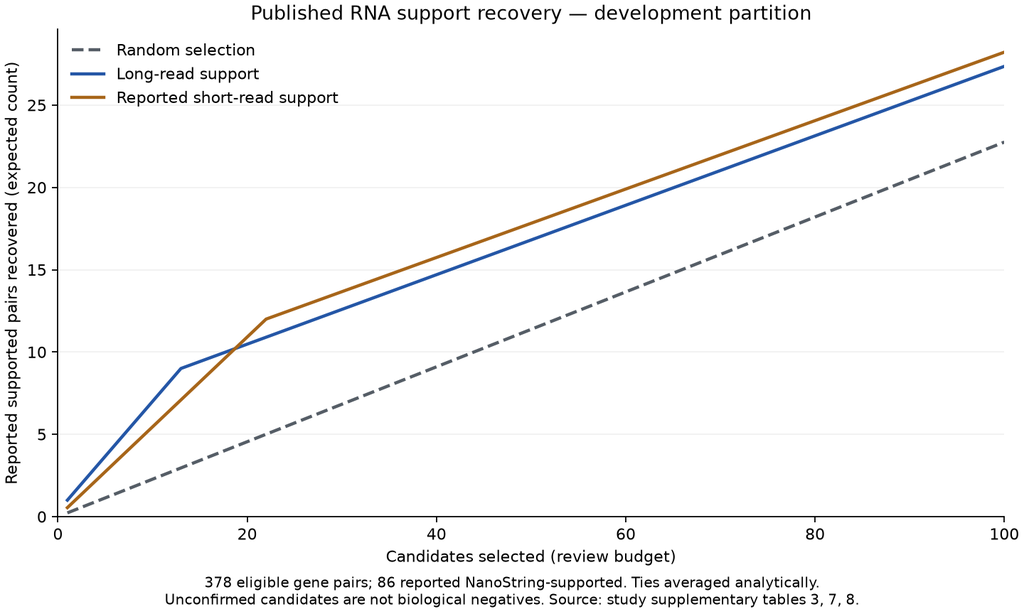

```python
figure_path = plot(root, partition='development')
display(Image(filename=str(figure_path)))
```

## Interpretation and next experiment

Read-based evidence already provides a meaningful baseline. Any sequence model should demonstrate added value over these methods. Most read-count scores are tied, so a single convenient ordering would be misleading. Before fitting a biological classifier, obtain suitable negative/assay-QC evidence or define and disclose a different estimand. Frozen RNA embeddings can be generated independently of these outcomes, but they are not yet part of this result.

The panel was selected by the original researchers. Recovery of its published support does not establish precision in unselected historical datasets. Exact-junction matching and an external study remain necessary extensions.

```python
import importlib.metadata as metadata
display(pd.DataFrame({'Package': ['chrna-prioritization','numpy','pandas','scipy','matplotlib'], 'Version': [metadata.version(x) for x in ['chrna-prioritization','numpy','pandas','scipy','matplotlib']]}))
```

|  | Package | Version |
| --- | --- | --- |
| 0 | chrna-prioritization | 0.1.0 |
| 1 | numpy | 2.5.3 |
| 2 | pandas | 3.0.6 |
| 3 | scipy | 1.18.1 |
| 4 | matplotlib | 3.11.2 |